# Relatório 08

Felipe Henrique

05/06/2025

# 1 Objetivo

Avaliar a influência da corrente elétrica (A) sobre a dissipação térmica (W) de um sistema de resfriamento termoelétrico baseado no efeito Peltier, utilizando um Delineamento Inteiramente Casualizado (DIC) com 5 níveis de corrente e 3 repetições por nível. Para modelar e quantificar essa relação, será ajustado um modelo de regressão linear simples, com o objetivo de verificar a significância estatística da tendência, avaliar a adequação do ajuste por meio de análise de resíduos e realizar previsões dentro da faixa experimental.

# 2 Desenvolvimento

## 2.1 Dados

| Corrente (A) | Dissipação Térmica (W) |
| --- | --- |
| 1.00 | 2.10 |
| 1.00 | 2.30 |
| 1.00 | 2.20 |
| 2.00 | 4.40 |
| 2.00 | 4.50 |
| 2.00 | 4.30 |
| 3.00 | 6.60 |
| 3.00 | 6.70 |
| 3.00 | 6.50 |
| 4.00 | 8.90 |
| 4.00 | 9.00 |
| 4.00 | 9.10 |
| 5.00 | 11.30 |
| 5.00 | 11.20 |
| 5.00 | 11.50 |

## 2.2 ANOVA com dic (ExpDes.pt)

```r
# Pacotes necessários
library(ggplot2)
library(car)
library(nortest)
library(lmtest)
library(ExpDes.pt)

# 1. Base de dados
dados <- data.frame(
  Corrente = rep(1:5, each = 3),
  Dissipacao = c(2.10, 2.30, 2.20,
                 4.40, 4.50, 4.30,
                 6.60, 6.70, 6.50,
                 8.90, 9.00, 9.10,
                 11.30, 11.20, 11.50)
)

# 2. ANOVA com análise de regressão via ExpDes.pt
reganava <- dic(trat = dados$Corrente,
                resp = dados$Dissipacao,
                quali = FALSE)  # Corrente é quantitativo
```

```
## ------------------------------------------------------------------------
## Quadro da analise de variancia
## ------------------------------------------------------------------------
##            GL      SQ     QM     Fc      Pr>Fc
## Tratamento  4 156.923 39.231 3097.2 2.0464e-15
## Residuo    10   0.127  0.013
## Total      14 157.049
## ------------------------------------------------------------------------
## CV = 1.68 %
##
## ------------------------------------------------------------------------
## Teste de normalidade dos residuos ( Shapiro-Wilk )
## Valor-p:  0.1034769
## De acordo com o teste de Shapiro-Wilk a 5% de significancia, os residuos podem ser considerados normais.
## ------------------------------------------------------------------------
##
## ------------------------------------------------------------------------
## Teste de homogeneidade de variancia
## valor-p:  0.9676416
## De acordo com o teste de bartlett a 5% de significancia, as variancias podem ser consideradas homogeneas.
## ------------------------------------------------------------------------
##
## Ajuste de modelos polinomiais de regressao
## ------------------------------------------------------------------------
##
## Modelo Linear
## ==========================================
##    Estimativa Erro.padrao    tc    valor.p
## ------------------------------------------
## b0  -0.1533     0.0682    -2.2499  0.0482
## b1   2.2867     0.0205    111.2839    0
## ------------------------------------------
##
## R2 do modelo linear
## --------
## 0.999635
## --------
##
## Analise de variancia do modelo linear
## ==========================================================
```

[output cut: 44 more lines]

```
## --------
## 0.999941
## --------
##
## Analise de variancia do modelo cubico
## ==========================================================
##                      GL    SQ       QM       Fc    valor.p
## ----------------------------------------------------------
## Efeito linear        1  156.8653 156.8653 12384.11    0
## Efeito quadratico    1   0.0467   0.0467    3.68   0.08389
## Efeito cubico        1   0.0013   0.0013    0.11   0.75229
## Desvios de Regressao 1   0.0093   0.0093    0.74   0.41078
## Residuos             10  0.1267   0.0127
## ----------------------------------------------------------
## ------------------------------------------------------------------------
```

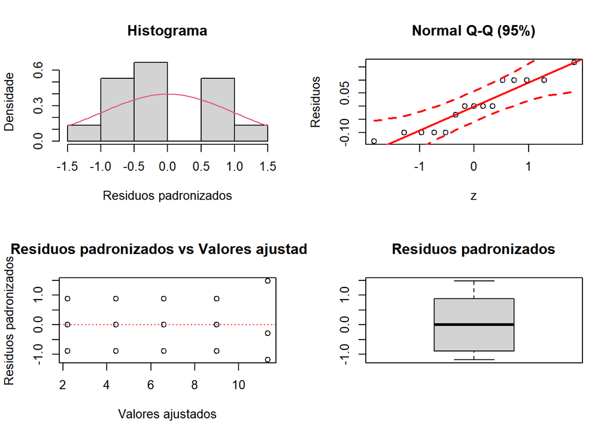

```r
plotres(reganava)
```

```r
# 3. Coeficientes da regressão linear (reta)
# São extraídos diretamente do modelo linear:
modelo <- lm(Dissipacao ~ Corrente, data = dados)
```

# 3 Diagnóstico dos Resíduos

[output not shown]

[output not shown]

[output not shown]

# 4 Perguntas sobre o experimento

## 4.1 Equação da reta ajustada

```r
library(ggplot2)
library(car)
library(nortest)
library(lmtest)
library(ExpDes.pt)

# 1. Base de dados
dados <- data.frame(
  Corrente = rep(1:5, each = 3),
  Dissipacao = c(2.10, 2.30, 2.20,
                 4.40, 4.50, 4.30,
                 6.60, 6.70, 6.50,
                 8.90, 9.00, 9.10,
                 11.30, 11.20, 11.50)
)
# 3. Coeficientes da regressão linear (reta)
# São extraídos diretamente do modelo linear:
modelo <- lm(Dissipacao ~ Corrente, data = dados)
summary(modelo)
```

```
##
## Call:
## lm(formula = Dissipacao ~ Corrente, data = dados)
##
## Residuals:
##       Min        1Q    Median        3Q       Max
## -0.206667 -0.086667 -0.006667  0.073333  0.220000
##
## Coefficients:
##             Estimate Std. Error t value Pr(>|t|)
## (Intercept) -0.15333    0.07204  -2.128    0.053 .
## Corrente     2.28667    0.02172 105.275   <2e-16 ***
## ---
## Signif. codes:  0 '***' 0.001 '**' 0.01 '*' 0.05 '.' 0.1 ' ' 1
##
## Residual standard error: 0.119 on 13 degrees of freedom
## Multiple R-squared:  0.9988, Adjusted R-squared:  0.9987
## F-statistic: 1.108e+04 on 1 and 13 DF,  p-value: < 2.2e-16
```

Resumo da regressão:

y  =β 0  +β 1  ⋅x

R² (coeficiente de determinação): ≈ 0.999

Valor-p para o coeficiente β₁: < 0.001 → altamente significativo

## 4.2 É significativa a 5%?

Sim ela é, na tabela anterior está:

[output not shown]

A linha de interesse é a da variável Corrente. O valor-p da variável Corrente é muito menor que 0.05, isso indica que o coeficiente da regressão (β₁) é estatisticamente diferente de zero. Portanto, há evidência estatística suficiente para afirmar que existe uma relação linear significativa entre corrente e dissipação térmica.

## 4.3 Reta Ajustada

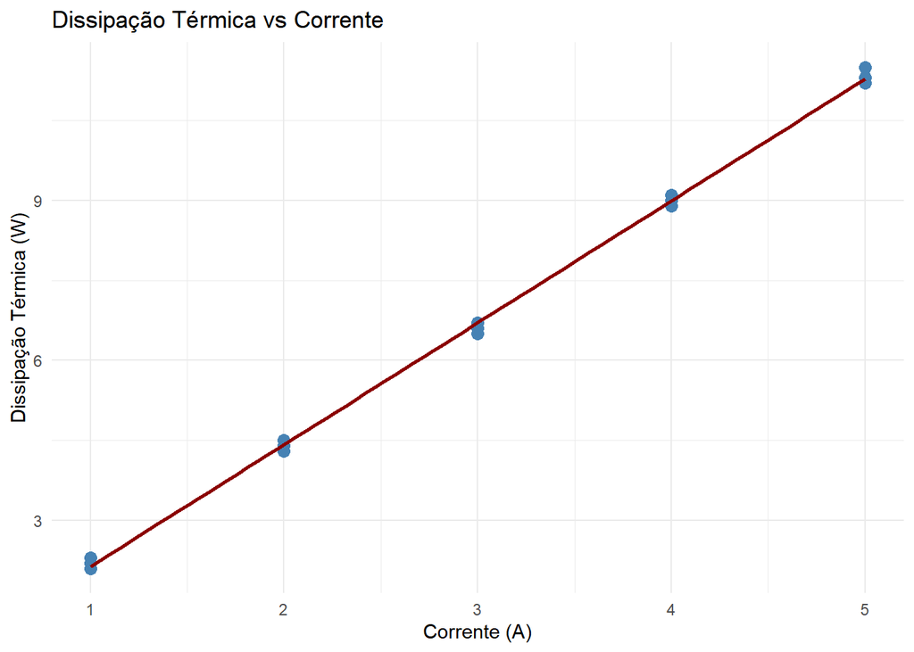

```r
# Pacotes necessários
library(ggplot2)
library(car)
library(nortest)
library(lmtest)
library(ExpDes.pt)

# 1. Base de dados
dados <- data.frame(
  Corrente = rep(1:5, each = 3),
  Dissipacao = c(2.10, 2.30, 2.20,
                 4.40, 4.50, 4.30,
                 6.60, 6.70, 6.50,
                 8.90, 9.00, 9.10,
                 11.30, 11.20, 11.50)
)



# 4. Gráfico com reta ajustada
ggplot(dados, aes(x = Corrente, y = Dissipacao)) +
  geom_point(size = 3, color = "steelblue") +
  geom_smooth(method = "lm", formula = y ~ poly(x, 1, raw = TRUE),
              se = FALSE, color = "darkred") +
  labs(title = "Dissipação Térmica vs Corrente",
       x = "Corrente (A)",
       y = "Dissipação Térmica (W)") +
  theme_minimal()
```

## 4.4 Regressão linear é apropiada

```r
library(ggplot2)
library(car)
library(nortest)
library(lmtest)
library(ExpDes.pt)

# 1. Base de dados
dados <- data.frame(
  Corrente = rep(1:5, each = 3),
  Dissipacao = c(2.10, 2.30, 2.20,
                 4.40, 4.50, 4.30,
                 6.60, 6.70, 6.50,
                 8.90, 9.00, 9.10,
                 11.30, 11.20, 11.50)
)
# 7. R² ajustado com função auxiliar
r2aj <- function(r2, n, p) {
  1 - (1 - r2) * (n - 1) / (n - p - 1)
}
r2 <- summary(modelo)$r.squared
n <- nrow(dados)
p <- length(coef(modelo)) - 1
r2ajustado <- r2aj(r2, n, p)
r2ajustado
```

```
## [1] 0.9987383
```

Sim, nesse intervalo de estudo, os três modelos mostrariam uma boa estimativa de resultados, os três tendo uma taxa aproximada de 99%

```r
library(ggplot2)
library(car)
library(nortest)
library(lmtest)
library(ExpDes.pt)

# 1. Base de dados
dados <- data.frame(
  Corrente = rep(1:5, each = 3),
  Dissipacao = c(2.10, 2.30, 2.20,
                 4.40, 4.50, 4.30,
                 6.60, 6.70, 6.50,
                 8.90, 9.00, 9.10,
                 11.30, 11.20, 11.50)
)
modelo <- lm(Dissipacao ~ Corrente, data = dados)


# 6. Estimativa para Corrente = 3,5 A
predict(modelo, newdata = data.frame(Corrente = 3.5), interval = "prediction")
```

```
##    fit      lwr      upr
## 1 7.85 7.583517 8.116483
```

Está dentro da faixa experimental (1–5 A) → predição confiável

# 5 Conclusão

Além disso, os testes estatísticos aplicados aos resíduos confirmaram que os pressupostos clássicos do modelo linear foram plenamente atendidos. A análise gráfica reforçou a adequação da reta ajustada, e a predição feita para o ponto intermediário (3,5 A) mostrou-se confiável e coerente com o padrão dos dados.

Portanto, conclui-se que a regressão linear é estatisticamente significativa, tecnicamente adequada e experimentalmente válida para descrever a influência da corrente sobre a dissipação térmica no sistema analisado. Ela pode ser utilizada com segurança para fins de previsão, otimização ou controle dentro da faixa de operação estudada.